# Math 300 NTI Lesson 22

CLT, Normal Distribution

Professor Bradley Warner

July, 2022

## Objectives

1. Explain the central limit theorem.
2. For a normal distribution, use `R` to find probabilities and percentiles.

## Reading

[Chapter 7.5](https://moderndive.com/7-sampling.html#sampling-conclusion-central-limit-theorem)

[Appendix A.2](https://moderndive.com/A-appendixA.html#appendix-normal-curve)

## Lesson

*Remember that you will be running this more like a lab than a lecture. You want them using `R` and answering questions. Have them open the notes rmd and work through it together.*

Work through the learning checks LCA.1 - LCA.2.

- The central limit theorem is difficult. The key idea is that if we create a point estimate that is using summation, then the **distribution of this point estimate** tends to be normal. The larger the sample, the closer the distribution is to being normal. If we are describing a sample mean, then the larger the sample, the smaller the standard error.
- Use `R` to find probabilities. This implies the use of `pnorm()` and `qnorm()`. You will need to spend time on the use of these functions.

Let’s do a simulation.

Suppose we record the time of arrival of 4 friends.

```r
library(tidyverse)
```

```r
set.seed(316)
(time<-round(runif(4,5,6),2))
```

```
## [1] 5.33 5.74 5.29 5.37
```

We are generating 4 random numbers in the interval 5 to 6. We record these and find the average.

Take a note to explain `runif(4,5,6)`. We are selecting 4 numbers at random between the values 5 and 6. Using `set.seed(316)` ensures we all end up with the same four numbers in this exercise.

```r
mean(time)
```

```
## [1] 5.4325
```

This is just one value. What is the distribution of the mean if we were to repeat this? Since this is a simulation, we can do this many, many times and plot the distribution of the mean. Don’t worry about the code for doing this.

```r
# Repeat this 1000 times
rep_data<-tibble(ave=replicate(1000,mean(round(runif(4,5,6),2))))
```

```r
summary(rep_data)
```

```
##       ave
##  Min.   :5.095
##  1st Qu.:5.402
##  Median :5.500
##  Mean   :5.508
##  3rd Qu.:5.603
##  Max.   :5.928
```

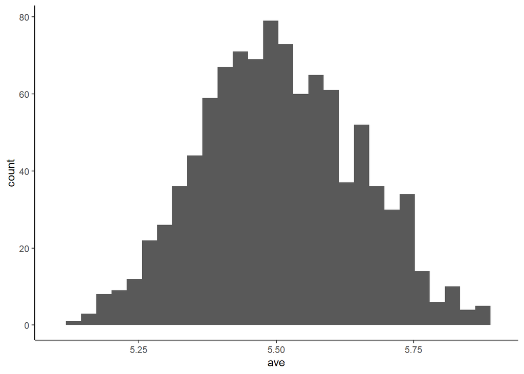

```r
ggplot(rep_data,aes(x=ave)) +
  geom_histogram() +
  xlim(5.1,5.9) +
  theme_classic()
```

Notice how this distribution of is approximately normal. This is a demonstration of the central limit theorem. If we used 10 points per sample instead of 4, the standard error would be smaller.

```r
# Repeat this 1000 times
rep_data2<-tibble(ave=replicate(1000,mean(round(runif(10,5,6),2))))
```

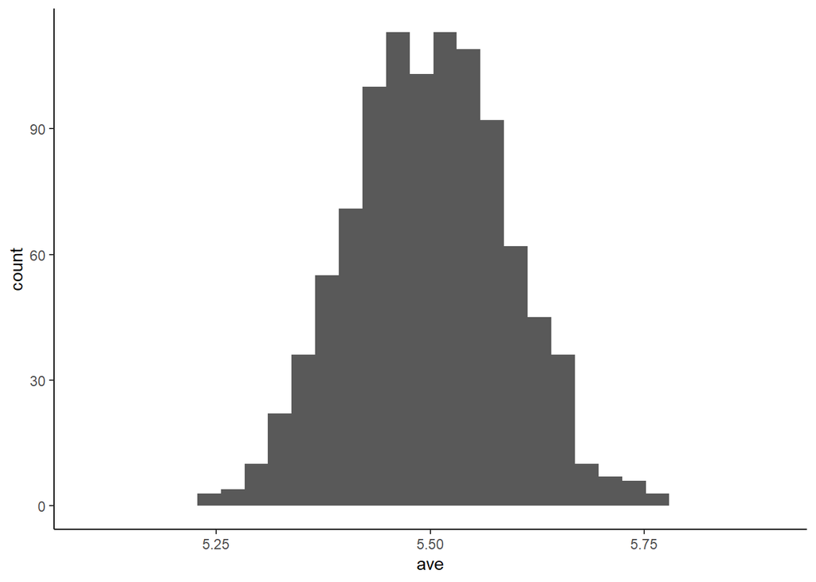

```r
ggplot(rep_data2,aes(x=ave)) +
  geom_histogram() +
  xlim(5.1,5.9) +
  theme_classic()
```

- Run the code again, but change the sample size to something larger.

### LC A.1 (Objective 2)

**(LCA.1)** Say you have a normal distribution with mean $\mu=6$ and standard deviation $\sigma=3$. What proportion of the area under the normal curve is less than 3? Greater than 12? Between 0 and 12?

**Solution:**

- Less than 3: 3 is one standard deviation less than the mean of 6, since $\frac{3 - \mu}{\sigma} = \frac{3-6}{3} = -1$. Thus we compute the area to the left of z = -1 in Figure A.2: 0.15% + 2.35% + 13.5% = 16%.

```r
pnorm(3,mean=6,sd=3)
```

```
## [1] 0.1586553
```

- Greater than 12: 12 is two standard deviations greater than the mean of 6, since $\frac{12 - \mu}{\sigma} = \frac{12-6}{3} = 2$, we compute the area to the right of z = 2 in Figure A.2: 2.35% + 0.15% = 2.5%.

```r
pnorm(12,mean=6,sd=3,lower.tail = FALSE)
```

```
## [1] 0.02275013
```

- Between 0 and 12: 0 is two standard deviations less than the mean of 6, since $\frac{0 - \mu}{\sigma} = \frac{0-6}{3} = -2$. Thus we compute the area between z = -2 and z = +2 in Figure A.2: 13.5% + 34% + 34% + 13.5% = 95%.

```r
pnorm(12,mean=6,sd=3)-pnorm(0,mean=6,sd=3)
```

```
## [1] 0.9544997
```

### LC A.2 (Objective 2)

**(LCA.2)** (Same normal distribution.) What is the 2.5th percentile of the area under the normal curve? The 97.5th percentile? The 100th percentile?

**Solution:**

- 2.5th percentile: Starting from the left of Figure A.2, since 0.15% + 2.35% = 2.5%, the 2.5th percentile is z = - 2. However, this is in standard units. Thus we need the value in the normal distribution that is two standard deviations lower than the mean: $\mu - 2 \cdot\sigma = 6 - 2 \cdot 3 = 0$.

```r
qnorm(.025,mean=6,sd=3)
```

```
## [1] 0.120108
```

This is not 0 since the figure is an approximation.

- 97.5th percentile: Starting from the left of Figure A.2, since 0.15% + 2.35% + 13.5% + 34% + 34% + 13.5% = 97.5%, the 97.5th percentile is z = +2. However, this is in standard units. Thus we need the value in the normal distribution that is two standard deviations higher than the mean: $\mu + 2 \cdot\sigma = 6 + 2 \cdot 3 = 12$.

```r
qnorm(.975,mean=6,sd=3)
```

```
## [1] 11.87989
```

- 100th percentile: $+\infty$. In other words, 100% of values will be less than positive infinity.

```r
qnorm(1,mean=6,sd=3)
```

```
## [1] Inf
```

## Documenting software

- File creation date: 2022-07-05
- R version 4.1.3 (2022-03-10)
- `tidyverse` package version: 1.3.1